# User Guide

Sheeja Manchira Krishnan

2020-07-02

```r
library(valueEQ5D)
```

## valueEQ5D

EQ-5D is a standardized instrument developed by the EuroQol(R) Group as a measure of health-related quality of life that can be used in a wide range of health conditions and treatments (https://euroqol.org/eq-5d-instruments/). The EQ-5D consists of a descriptive system and a visual analog scale (VAS).

The descriptive system comprises five dimensions: mobility, self-care, usual activities, pain/discomfort and anxiety/depression. The EQ-5D VAS records the patient’s self-rated health on a vertical visual analogue scale. This can be used as a quantitative measure of health outcome that reflects the patient’s own judgement. The scores on these five dimensions can be presented as a health profile or can be converted to a single summary index number (utility) reflecting preferability compared to other health profiles.

Currently three versions of EQ-5D exist:

EQ-5D with 3 levels of severity for each of the 5 dimensions: EQ-5D-3L EQ-5D with 5 levels of severity for each of the 5 dimensions: EQ-5D-5L EQ-5D for use in children: EQ-5D-Y

This package can be used for valuing the adult EQ-5D descriptive system scores - both 5L and 3L for different countries. EQ-5D-5L scores can be valued for the following countries: Canada,China,England,Ethiopia,France,Germany,Hong Kong,Indonesia,Ireland,Japan, Korea,Malaysia,Netherlands,Poland,Portugal,Spain,Taiwan,Thailand, Uruguay, USA and Vietnam.

```
Canada: Xie et al (2016) <doi:10.1097/MLR.0000000000000447>
China:Luo et al (2017) <doi:10.1016/j.jval.2016.11.016>
England: Devlin et al (2018) <doi:10.1002/hec.3564>
Ethiopia: Welie et al (2019) <doi:10.1016/j.vhri.2019.08.475>
France:Andrade et al (2019) <doi::10.1007/s40273-019-00876-4>
Germany: Ludwig et al (2018) <doi:10.1007/s40273-018-0615-8>
Hong Kong: Wong et al (2018) <doi:10.1007/s40271-017-0278-0>
Indonesia: Purba et al (2017) <doi:10.1007/s40273-017-0538-9>
Ireland: Hobbins et al (2016) <doi:10.1007/s40273-018-0690-x>
Japan: Shiroiwa, et al (2016) <doi:10.1016/j.jval.2016.03.1834>
Korea: Kim et al (2016) <doi:10.1007/s11136-015-1205-2>
Malaysia: Shafie  et al (2019) <doi:10.1007/s40273-018-0758-7>
Netherlands: Versteegh et al (2016) <doi:10.1016/j.jval.2016.01.003>
Poland: Golicki et al <doi:10.1007/s40273-019-00811-7>
Portugal:Ferreira1 et al (2014) <doi:10.1007/s11136-019-02226-5>
Spain: Ramos-Goñiet et al (2018) <https://doi.org/10.1016/j.jval.2017.10.023>
Taiwan:  Lin et al (2018)  <https://doi.org/10.1371/journal.pone.0209344>
Thailand: Pattanaphesaj et al (2018) <doi:10.1080/14737167.2018>
Uruguay: Augustovski et al (2016) <doi:10.1007/s11136-015-1086-4>
USA: Pickard et al (2019) <doi:10.1016/j.jval.2019.02.009>
Vietnam: Mai et al (2020) <doi:10.1007/s11136-020-02469-7>
```

EQ-5D-3L scores can be valued for the countries Argentina, Australia,Belgium, Brazil, Canada, Chile, China, Denmark, Europe, Finland, France, Germany, Iran, Italy,Japan,Korea, Malaysia, Netherlands, New Zealand,Poland,Portugal,Singapore,Slovenia,Spain,Sri Lanka, Sweden, Taiwan,Thailand,Trinidad and Tobago, UK,USA,and Zimbabwe.

```
Argentina: Augustovski et al (2009) <doi:10.1111/j.1524-4733.2008.00468.x>
Australia: Viney et al (2011) <doi:10.1016/j.jval.2011.04.009>
Belgium: Cleemput et al (2010) <doi:10.1007/s10198-009-0167-0>
Brazil: Santos et al (2016) <doi:10.1177/0272989X15613521>
Canada: Bansback et al (2012) <https://doi.org/10.1371/journal.pone.0031115>
Chile: Zarate et al (2011) <doi:10.1016/j.jval.2011.09.002.
China: Liu et al (2014) <doi:10.1016/j.jval.2014.05.007>
Denmark TTO: Wittrup-Jensen et al (2009) <doi:10.1177/1403494809105287>
Denmark VAS: Szende et al (2014) <doi:10.1007/978-94-007-7596-1>
Europe: Szende et al (2014) <doi:10.1007/978-94-007-7596-1>
Finland: Szende et al (2014) <doi:10.1007/978-94-007-7596-1>
France: Chevalier et al (2013) <doi:10.1007/s10198-011-0351-x>
Germany (TTO): Greiner et al (2005) <doi:10.1007/s10198-004-0264-z>
Germany (VAS): Szende et al (2014) <doi:10.1007/978-94-007-7596-1>
Iran: Goudarzi et al (2019) <doi:10.1016/j.vhri.2019.01.007>
Italy: Scalone et al (2013) <http://dx.doi.org/10.1016/j.jval.2013.04.008>
Japan: Tsuchiya et al (2002) <https://doi.org/10.1002/hec.673>
Korea: Lee et al <doi:10.1111/j.1524-4733.2009.00579.x>
Malaysia: Yusof et al (2019) <doi:10.1016/j.jval.2011.11.024>
Netherlands: Lamers et al <doi:10.1002/hec.1124>
New Zealand: Devlin et al <doi:10.1002/hec.741>
Poland: Golicki et al <https://doi.org/10.1111/j.1524-4733.2009.00596.x>
Portugal: Ferreira et al <doi:10.1007/s11136-013-0448-z>
Singapore: Nan Luo et al <doi:10.1007/s40273-014-0142-1>
Slovenia: Szende et al (2014) <doi:10.1007/978-94-007-7596-1>
Spain (TTO): Badia et al (2001) <doi:10.1177/0272989X0102100102>
Spain (VAS): Szende et al (2014) <doi:10.1007/978-94-007-7596-1>
Sri Lanka: Kularatna et al (2015) <doi:10.1007/s11136-014-0906-2>
Sweden: Burström et al (2014) <doi:10.1007/s11136-013-0496-4>
Taiwan: Lee et al (2013) <http://dx.doi.org/10.1016/j.jfma.2012.12.015>
Thailand: Tongsiri et al (2011) <doi:10.1016/j.jval.2011.06.005>
Trinidad and Tobago: Bailey et al (2016)     <http://dx.doi.org/10.1016/j.vhri.2016.07.010>
UK (TTO): Dolan et al (1997) <http://dx.doi.org/10.1097/00005650-199711000-00002>
UK (VAS): Szende et al (2014) <doi:10.1007/978-94-007-7596-1>
USA: Shaw et al (2005) <doi:10.1097/00005650-200503000-00003>
Zimbabwe: Jelsma et al (2003) <https://doi.org/10.1186/1478-7954-1-11>
```

The 5L descriptive scores can be mapped to 3L index values for 10 countries using the NICE recommended Van Hout et al. method.

If the individual responses are in column formats (e.g. in csv) they can be used as arguments in the methods.

If the requirement is to get the summary statistics of collected EQ-5D responses from many individuals with conditions on gender and age use these methods: valuing EQ-5D-3L responses use “value3L”;for valuing EQ-5D-5L responses, use “value5L”; and for mapping EQ-5D-5L responses to EQ-5D-3L index values, use “map5Lto3L”. The arguments for all these three parameters will be country names and followed by the five column names of the EQ-5D responses and the data containing these EQ-5D responses.

EQ-5D-5L responses for England are converted to index values using Devlin et al. method. EQ-5D-3L responses for England are converted to index values using Dolan et al. method. EQ-5D-5L responses for England are mapped to EQ-5D-3L index values using Van Hout et al. method.

Whenever the EQ-5D-5L responses are taken as input parameters, code checks if the input values are with in the bounds, i.e for 3L they have to be between 1 and 3 and for 5L between 1 and 5, throws error otherwise.

## Data

For demonstration purposes, a simulated data set representing treatment and control arm of randomised controlled trial will be used. If any of the responses are invalid i.e other than 1 to 5 for EQ-5D-5L or 1 to 3 for EQ-5D-3L, it will throw error and return -1.

```r
## EQ-5D-3L data
 set.seed(17)
  EQ5D3Ldata <- data.frame(age=abs(rnorm(10, 60, 20)),
                           sex=factor(sample(c("M", "F"), 10, replace=T)),
                           arm=factor(sample(c("Control", "Intervention"), 10, replace=T)),
                           eq5d3L.q1=(sample(c(1,2,3), 10, replace=T)),
                           eq5d3L.q2=(sample(c(1,2,3), 10, replace=T)),
                           eq5d3L.q3=(sample(c(1,2,3), 10, replace=T)),
                           eq5d3L.q4=(sample(c(1,2,3), 10, replace=T)),
                           eq5d3L.q5=(sample(c(1,2,3), 10, replace=T)))

  ## EQ-5D-5L data
 set.seed(17)
  EQ5D5Ldata <- data.frame(age=abs(rnorm(10, 60, 20)),
                           sex=factor(sample(c("M", "F"), 10, replace=T)),
                           arm=factor(sample(c("Control", "Intervention"), 10, replace=T)),
                           eq5d5L.q1=(sample(c(1,2,3,4,5), 10, replace=T)),
                           eq5d5L.q2=(sample(c(1,2,3,4,5), 10, replace=T)),
                           eq5d5L.q3=(sample(c(1,2,3,4,5), 10, replace=T)),
                           eq5d5L.q4=(sample(c(1,2,3,4,5), 10, replace=T)),
                           eq5d5L.q5=(sample(c(1,2,3,4,5), 10, replace=T)))
```

## Examples- Valuing EQ-5D-3L

```r
## Valuing EQ-5D-3L individual score
 value3LInd("UK","TTO",1,2,3,2,2)
```

```
#> [1] 0.258
```

```r
 value3LInd("UK","VAS",c(1,2,3,2,2))
```

```
#> [1] 0.309
```

```r
 value3LInd("UK","TTO",12322)
```

```
#> [1] 0.258
```

When the data is in column format as in example below, use the ‘value3L’ to get the summary statistics while returning back the modified data. Use conditions if the results need to be based on a particular gender or particular age group as in the examples below. This will provide the summary statistics, frequency table, histogram and modified data

```r
result1<-value3L(EQ5D3Ldata,"eq5d3L.q1","eq5d3L.q2","eq5d3L.q3","eq5d3L.q4","eq5d3L.q5","UK","TTO",NULL,NULL)
```

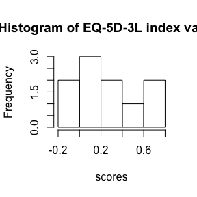

The results can be called using the stats,frequencyTable, histogram and modifiedData which are given below.

```r
result1$stats
```

```
#>            Sum   Mean        SD Median  Mode         SE Minimum Maximum
#> EQ-5D-3L 2.645 0.2645 0.2975441  0.212 0.159 0.09409171  -0.127   0.744
#>          Count
#> EQ-5D-3L    10
```

```r
result1$frequencyTable
```

```
#>                     scores                Freq Cumul relative
#> -0.127              "-0.127"              "1"  "1"   "0.1"
#> -0.0410000000000001 "-0.0410000000000001" "1"  "2"   "0.1"
#> 0.051               "0.051"               "1"  "3"   "0.1"
#> 0.159               "0.159"               "2"  "5"   "0.2"
#> 0.265               "0.265"               "1"  "6"   "0.1"
#> 0.277               "0.277"               "1"  "7"   "0.1"
#> 0.414               "0.414"               "1"  "8"   "0.1"
#> 0.744               "0.744"               "2"  "10"  "0.2"
```

```r
result1$histogram
```

```
#> $breaks
#> [1] -0.2  0.0  0.2  0.4  0.6  0.8
#>
#> $counts
#> [1] 2 3 2 1 2
#>
#> $density
#> [1] 1.0 1.5 1.0 0.5 1.0
#>
#> $mids
#> [1] -0.1  0.1  0.3  0.5  0.7
#>
#> $xname
#> [1] "scores"
#>
#> $equidist
#> [1] TRUE
#>
#> attr(,"class")
#> [1] "histogram"
```

```r
result1$modifiedData
```

```
#>         age sex          arm eq5d3L.q1 eq5d3L.q2 eq5d3L.q3 eq5d3L.q4
#> 1  39.69983   F      Control         3         3         1         1
#> 2  58.40727   F      Control         2         1         2         3
#> 3  55.34026   F Intervention         1         2         1         1
#> 4  43.65464   F      Control         2         1         1         3
#> 5  75.44182   F Intervention         1         2         1         1
#> 6  56.68776   M      Control         1         3         2         2
#> 7  79.45749   F Intervention         3         2         1         2
#> 8  94.33068   F Intervention         3         1         1         1
#> 9  65.10474   F Intervention         1         1         1         1
#> 10 67.33162   M Intervention         2         1         2         3
#>    eq5d3L.q5 EQ-5D-3L scores
#> 1          2           0.051
#> 2          1           0.159
#> 3          2           0.744
#> 4          3          -0.041
#> 5          2           0.744
#> 6          1           0.277
#> 7          3          -0.127
#> 8          2           0.265
#> 9          3           0.414
#> 10         1           0.159
```

Similarly, we can use the options to get the results for particular gender with given age ranges.

```r
result2<-value3L(EQ5D3Ldata,"eq5d3L.q1","eq5d3L.q2","eq5d3L.q3","eq5d3L.q4","eq5d3L.q5","UK","TTO","male",c(10,70))
```

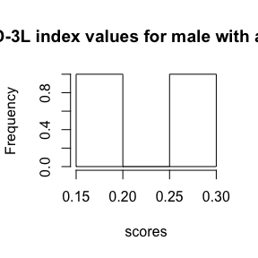

```r
result3<-value3L(EQ5D3Ldata,"eq5d3L.q1","eq5d3L.q2","eq5d3L.q3","eq5d3L.q4","eq5d3L.q5","UK","TTO","male",NULL)
```

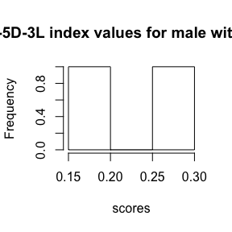

```r
result4<-value3L(EQ5D3Ldata,"eq5d3L.q1","eq5d3L.q2","eq5d3L.q3","eq5d3L.q4","eq5d3L.q5","UK","TTO",NULL,c(10,70))
```

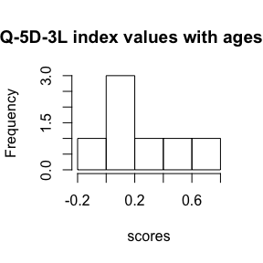